# Morning Practical

# Ozone Modelling

- Get the data

```r
ozone <- read.table("../workshop_JGI_2018/exercises/data/ozone.txt")
```

- Look at the data

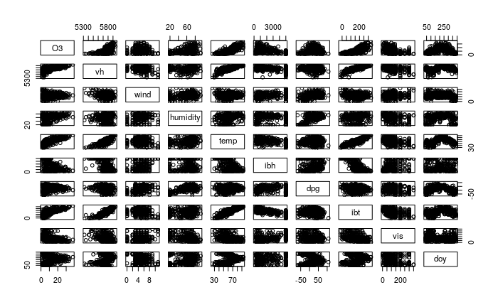

```r
pairs(ozone)
```

- Load required packages

```r
library(mgcViz)
```

- Fit a Gaussian GAM with 03 as a response, where log(E(03)) is given by the sum of smooth functions

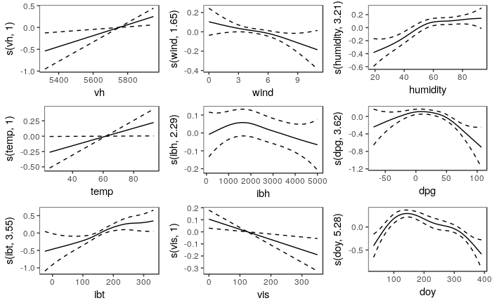

```r
ozone_gam <- gamV(O3 ~ s(vh) + s(wind) + s(humidity) + s(temp) + s(ibh) + s(dpg) + s(ibt) + s(vis) + s(doy),
             family = gaussian(link = log),
             data = ozone,
             aViz = list(nsim = 50))
print(plot(ozone_gam, allTerms = TRUE), pages = 1) # plot() calls plot.gamViz(). See ?plot.gamViz
```

- Check the model residuals

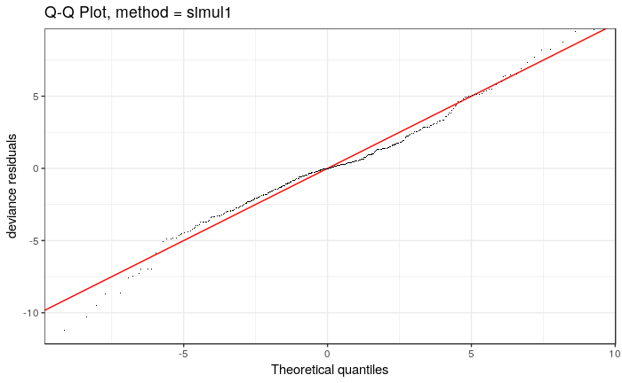

```r
qq(ozone_gam)
```

```
Method: REML   Optimizer: outer newton
full convergence after 9 iterations.
Gradient range [-0.0002158495,0.0002554058]
(score 910.9445 & scale 11.71282).
Hessian positive definite, eigenvalue range [1.316953e-05,160.0585].
Model rank =  82 / 82

Basis dimension (k) checking results. Low p-value (k-index<1) may
indicate that k is too low, especially if edf is close to k'.

              k'  edf k-index p-value
s(vh)       9.00 1.00    1.06   0.860
s(wind)     9.00 1.65    0.99   0.375
s(humidity) 9.00 3.21    1.09   0.955
s(temp)     9.00 1.00    1.05   0.800
s(ibh)      9.00 2.29    0.92   0.055 .
s(dpg)      9.00 3.62    1.06   0.875
s(ibt)      9.00 3.55    0.96   0.230
s(vis)      9.00 1.00    1.03   0.710
s(doy)      9.00 5.28    0.95   0.180
---
Signif. codes:  0 ‘***’ 0.001 ‘**’ 0.01 ‘*’ 0.05 ‘.’ 0.1 ‘ ’ 1
```

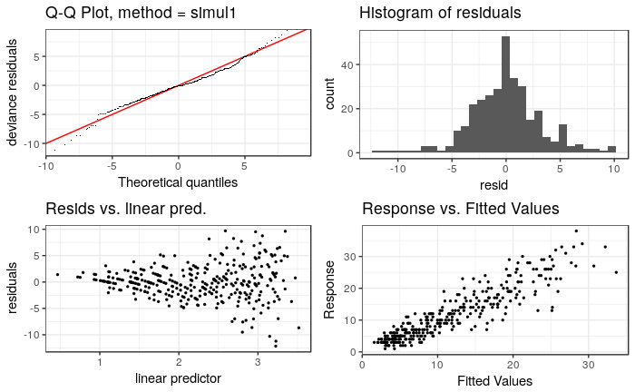

```r
check(ozone_gam)
```

- Refit using a gamma distribution, does this improve fit?

```
Method: REML   Optimizer: outer newton
full convergence after 11 iterations.
Gradient range [-0.0002389315,0.000824498]
(score 848.4114 & scale 0.08506619).
Hessian positive definite, eigenvalue range [1.192509e-05,165.0888].
Model rank =  82 / 82

Basis dimension (k) checking results. Low p-value (k-index<1) may
indicate that k is too low, especially if edf is close to k'.

              k'  edf k-index p-value
s(vh)       9.00 1.00    1.05    0.88
s(wind)     9.00 1.00    0.95    0.24
s(humidity) 9.00 2.48    1.03    0.70
s(temp)     9.00 3.28    1.05    0.86
s(ibh)      9.00 2.85    0.96    0.24
s(dpg)      9.00 4.29    1.01    0.60
s(ibt)      9.00 1.00    0.86    0.01 **
s(vis)      9.00 3.00    1.00    0.54
s(doy)      9.00 5.43    0.92    0.06 .
---
Signif. codes:  0 ‘***’ 0.001 ‘**’ 0.01 ‘*’ 0.05 ‘.’ 0.1 ‘ ’ 1
```

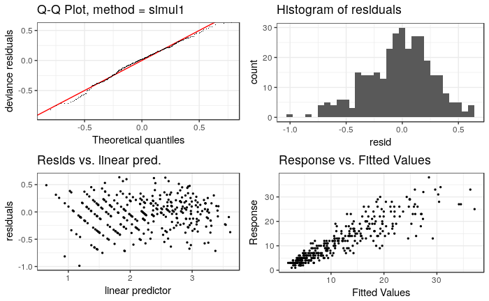

```r
ozone_gam_gamma <- gamV(O3 ~ s(vh) + s(wind) + s(humidity) + s(temp) + s(ibh) + s(dpg) + s(ibt) + s(vis) + s(doy),
             family = Gamma(link = log),
             data = ozone,
             aViz = list(nsim = 50))
check(ozone_gam_gamma)
```

- Fit alternative model with an indentity-link

```r
ozone_gam_gamma_id <- gamV(O3 ~ s(vh) + s(wind) + s(humidity) + s(temp) + s(ibh) + s(dpg) + s(ibt) + s(vis) + s(doy),
             family = Gamma(link = identity),
             data = ozone,
             aViz = list(nsim = 50))
AIC(ozone_gam_gamma, ozone_gam_gamma_id)
```

|  | df | AIC |
| --- | --- | --- |
| ozone_gam_gamma | 30.37103 | 1652.173 |
| ozone_gam_gamma_id | 38.92798 | 1676.394 |

- Plot the smoothed effects

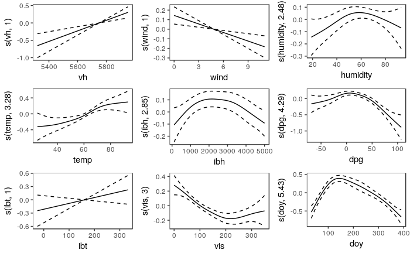

```r
print(plot(ozone_gam_gamma, allTerms = TRUE), pages = 1)
```

```r
summary(ozone_gam_gamma)
```

```
Family: Gamma
Link function: log

Formula:
O3 ~ s(vh) + s(wind) + s(humidity) + s(temp) + s(ibh) + s(dpg) +
    s(ibt) + s(vis) + s(doy)

Parametric coefficients:
            Estimate Std. Error t value Pr(>|t|)
(Intercept)  2.25587    0.01606   140.5   <2e-16 ***
---
Signif. codes:  0 ‘***’ 0.001 ‘**’ 0.01 ‘*’ 0.05 ‘.’ 0.1 ‘ ’ 1

Approximate significance of smooth terms:
              edf Ref.df      F  p-value
s(vh)       1.000  1.000 13.779 0.000243 ***
s(wind)     1.000  1.000  9.885 0.001826 **
s(humidity) 2.483  3.126  2.051 0.097971 .
s(temp)     3.279  4.124  3.785 0.004743 **
s(ibh)      2.846  3.482  4.717 0.002306 **
s(dpg)      4.292  5.375 12.376 1.98e-11 ***
s(ibt)      1.002  1.004  1.851 0.174635
s(vis)      3.000  3.753 10.350 2.36e-07 ***
s(doy)      5.433  6.624 24.170  < 2e-16 ***
---
Signif. codes:  0 ‘***’ 0.001 ‘**’ 0.01 ‘*’ 0.05 ‘.’ 0.1 ‘ ’ 1

R-sq.(adj) =  0.785   Deviance explained =   83%
-REML = 848.41  Scale est. = 0.085066  n = 330
```

- Simplify the model using p value selection (bad)

```r
ozone_gam_gamma_rest <- gamV(O3 ~ s(vh) + s(wind) + s(temp) + s(ibh) + s(dpg) + s(vis) + s(doy),
             family = Gamma(link = identity),
             data = ozone,
             aViz = list(nsim = 50))
AIC(ozone_gam_gamma_id, ozone_gam_gamma_rest)
```

|  | df | AIC |
| --- | --- | --- |
| ozone_gam_gamma_id | 38.92798 | 1676.394 |
| ozone_gam_gamma_rest | 33.53471 | 1680.653 |

- Interpret the smoothed effects, Q example of interpreting this?

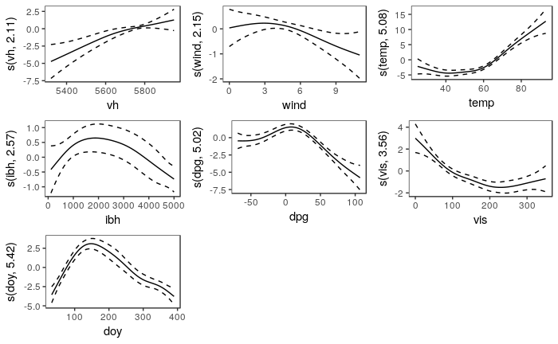

```r
print(plot(ozone_gam_gamma_rest, allTerms = TRUE), pages = 1)
```

# Bone mineral density modelling

- Get the calcium data

```r
load("../workshop_JGI_2018/exercises/data/calcium.rda")
```

- Fit a simple model with `bmd` as the reponse and linear effects for `age` and `groups`.

```r
linear_gam <- gamV(bmd ~ group + age, data = calcium, aViz = list(nsim = 100))
summary(linear_gam)
```

```
Family: gaussian
Link function: identity

Formula:
bmd ~ group + age

Parametric coefficients:
             Estimate Std. Error t value Pr(>|t|)
(Intercept)  0.337882   0.051553   6.554  1.4e-10 ***
groupP      -0.019539   0.006055  -3.227  0.00133 **
age          0.049501   0.004282  11.560  < 2e-16 ***
---
Signif. codes:  0 ‘***’ 0.001 ‘**’ 0.01 ‘*’ 0.05 ‘.’ 0.1 ‘ ’ 1


R-sq.(adj) =  0.221   Deviance explained = 22.4%
-REML = -625.72  Scale est. = 0.004589  n = 501
```

- Check residuals if to see in mean depends on the subject

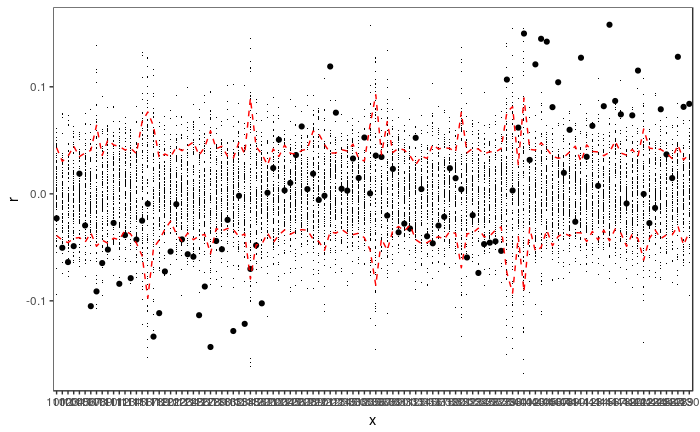

```r
check1D(linear_gam, calcium$person) + l_gridCheck1D(mean)
```

- Add random effect for subjects

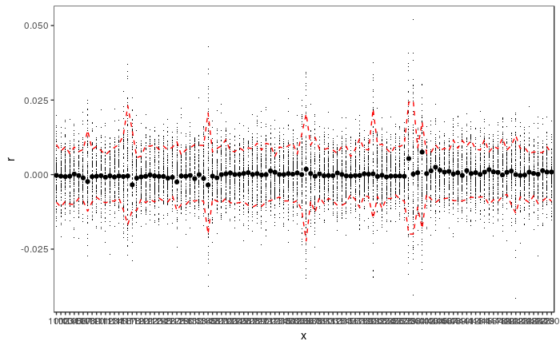

```r
check1D(cal_rf_per, calcium$person) + l_gridCheck1D(mean)
summary(cal_rf_per)
```

```
Family: gaussian
Link function: identity

Formula:
bmd ~ group + age + s(person, bs = "re")

Parametric coefficients:
             Estimate Std. Error t value Pr(>|t|)
(Intercept)  0.329263   0.015168  21.707   <2e-16 ***
groupP      -0.019323   0.012785  -1.511    0.132
age          0.050217   0.001017  49.394   <2e-16 ***
---
Signif. codes:  0 ‘***’ 0.001 ‘**’ 0.01 ‘*’ 0.05 ‘.’ 0.1 ‘ ’ 1

Approximate significance of smooth terms:
            edf Ref.df     F p-value
s(person) 108.4    110 82.75  <2e-16 ***
---
Signif. codes:  0 ‘***’ 0.001 ‘**’ 0.01 ‘*’ 0.05 ‘.’ 0.1 ‘ ’ 1

R-sq.(adj) =   0.96   Deviance explained = 96.9%
-REML = -1121.3  Scale est. = 0.00023803  n = 501
```

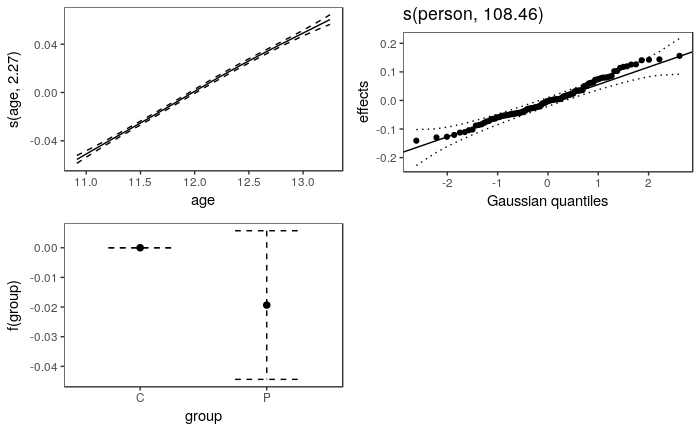

```r
col_age_smooth <- gamV(bmd ~ group + s(age) + s(person, bs = "re"), data = calcium)
print(plot(col_age_smooth, allTerms = T), pages = 1)
```

- Check to see if age impact is different between age group using a by factor.

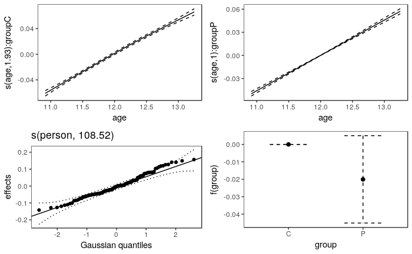

- Look at model differences

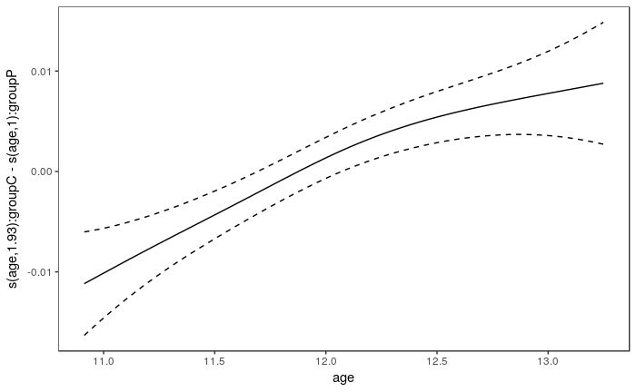

```r
plotDiff(sm(col_age_smooth_by_age, 1),
         sm(col_age_smooth_by_age, 2)) + l_fitLine() + l_ciLine()
```

# Forecasting electricity demand on GEFCOM2014 data

- Get the GEF com 2014 data
- Fit a Guassian GAM, with smooth effects for some variables and parameteric effects for others.

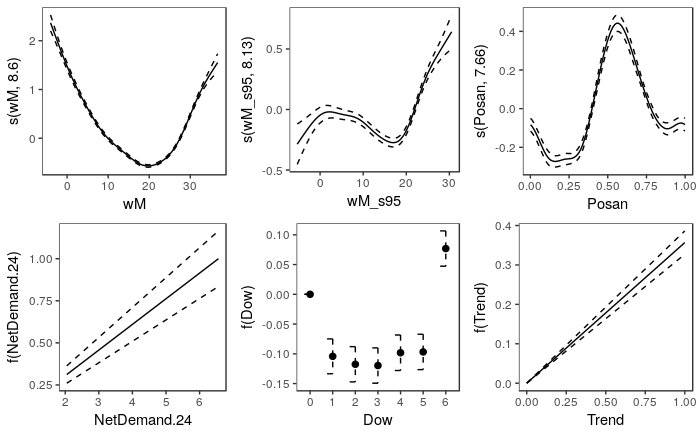

```r
baseline_gef <- gamV(NetDemand ~ NetDemand.24 + Dow + Trend + s(wM) + s(wM_s95) + s(Posan, bs = "cc"),
             data = gefcom_small, aViz = list(nsim = 50))
print(plot(baseline_gef, allTerms = TRUE), pages = 1)
```

- Check the mean of residuals depending on Trend.

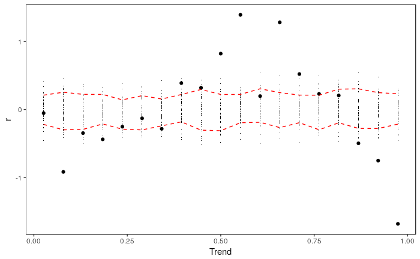

```r
check1D(baseline_gef, "Trend") + l_gridCheck1D()
```

```
Method: REML   Optimizer: outer newton
full convergence after 7 iterations.
Gradient range [-0.0002690126,0.000237972]
(score -397.9388 & scale 0.04001808).
Hessian positive definite, eigenvalue range [3.287508,1255.534].
Model rank =  35 / 35

Basis dimension (k) checking results. Low p-value (k-index<1) may
indicate that k is too low, especially if edf is close to k'.

            k'  edf k-index p-value
s(wM)     9.00 8.60    0.91  <2e-16 ***
s(wM_s95) 9.00 8.13    1.02    0.79
s(Posan)  8.00 7.66    1.04    0.98
---
Signif. codes:  0 ‘***’ 0.001 ‘**’ 0.01 ‘*’ 0.05 ‘.’ 0.1 ‘ ’ 1
```

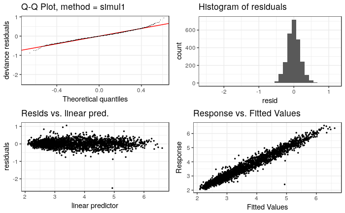

```r
check(baseline_gef)
```

```
Method: REML   Optimizer: outer newton
full convergence after 7 iterations.
Gradient range [-4.001714e-06,2.372158e-06]
(score -517.8392 & scale 0.03582405).
Hessian positive definite, eigenvalue range [1.824204,1255.579].
Model rank =  59 / 59

Basis dimension (k) checking results. Low p-value (k-index<1) may
indicate that k is too low, especially if edf is close to k'.

             k'   edf k-index p-value
s(Trend)   5.00  4.58    0.78  <2e-16 ***
s(wM)     19.00 13.81    0.96    0.02 *
s(wM_s95) 14.00 10.14    1.02    0.85
s(Posan)  13.00 11.51    1.00    0.63
---
Signif. codes:  0 ‘***’ 0.001 ‘**’ 0.01 ‘*’ 0.05 ‘.’ 0.1 ‘ ’ 1
```

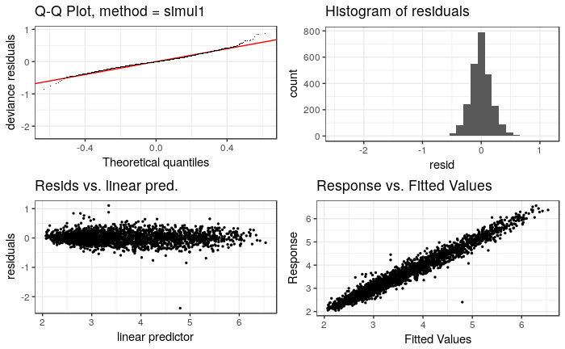

```r
check(gef_smooth)
```

- Check qq plot

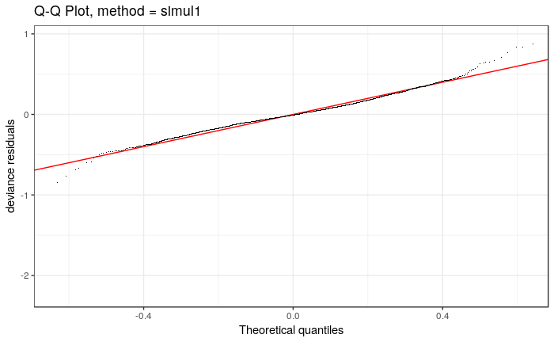

- Refit using a scaled students T distribution.

```r
gef_scat <- gamV(NetDemand ~ NetDemand.24 + Dow + s(Trend, k = 6) + s(wM, k = 20) +
             s(wM_s95, k = 15) + s(Posan, k = 15, bs = "cc"), data = gefcom_small,
             family = scat,
             aViz = list(nsim = 50))

AIC(gef_smooth, gef_scat)

qq(gef_scat)
```

[output not shown]

- Consider log link

```r
gef_scat_log <- gamV(NetDemand ~ NetDemand.24 + Dow + s(Trend, k = 6) + s(wM, k = 20) +
             s(wM_s95, k = 15) + s(Posan, k = 15, bs = "cc"),
             data = gefcom_small,
             family = scat(link = log),
             aViz = list(nsim = 50))
AIC(gef_scat, gef_scat_log)
```

|  | df | AIC |
| --- | --- | --- |
| gef_scat | 52.62690 | -1469.648 |
| gef_scat_log | 53.19137 | -1490.144 |

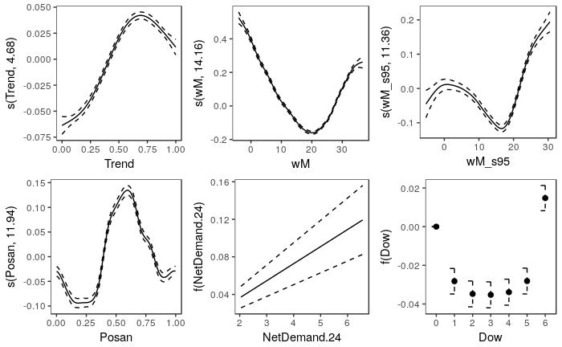

```r
print(plot(gef_scat_log, allTerms = TRUE), pages = 1)
```